# Analysis of Bike Sharing Rides with Bay Wheels Data

```python
df_clean.sample(30)
```

|  | bike_id | bike_share_for_all_trip | duration_sec | end_station_id | end_station_latitude | end_station_longitude | end_station_name | end_time | member_birth_year | member_gender | rental_access_method | start_station_id | start_station_latitude | start_station_longitude | start_station_name | start_time | user_type | age | duration_min | city |
| --- | --- | --- | --- | --- | --- | --- | --- | --- | --- | --- | --- | --- | --- | --- | --- | --- | --- | --- | --- | --- |
| 1446956 | 3169 | No | 1202 | 163.0 | 37.797320 | -122.265320 | Lake Merritt BART Station | 2018-08-08 19:11:14.376 | 1978.0 | Female | other | 193.0 | 37.812744 | -122.247215 | Grand Ave at Santa Clara Ave | 2018-08-08 18:51:11.450 | Customer | 41 | 20 | Oakland |
| 123046 | 670 | NaN | 618 | 3.0 | 37.786375 | -122.404904 | Powell St BART Station (Market St at 4th St) | 2017-09-07 12:51:44.886 | 1960.0 | Male | other | 59.0 | 37.774814 | -122.418954 | S Van Ness Ave at Market St | 2017-09-07 12:41:26.671 | Subscriber | 59 | 10 | San Francisco |
| 2793527 | 5563 | No | 491 | 171.0 | 37.844279 | -122.251900 | Rockridge BART Station | 2019-03-29 18:30:33.394 | 1985.0 | Female | other | 212.0 | 37.824893 | -122.260437 | Mosswood Park | 2019-03-29 18:22:21.885 | Subscriber | 34 | 8 | Oakland |
| 1769646 | 2270 | No | 840 | 356.0 | 37.769188 | -122.422285 | Valencia St at Clinton Park | 2018-10-02 17:42:27.278 | 1981.0 | Male | other | 36.0 | 37.783830 | -122.398870 | Folsom St at 3rd St | 2018-10-02 17:28:27.131 | Subscriber | 38 | 14 | San Francisco |
| 2408 | 105 | NaN | 644 | 15.0 | 37.795392 | -122.394203 | San Francisco Ferry Building (Harry Bridges Pl... | 2017-07-01 09:44:46.507 | 1980.0 | Male | other | 66.0 | 37.778742 | -122.392741 | 3rd St at Townsend St | 2017-07-01 09:34:01.939 | Subscriber | 39 | 10 | San Francisco |
| 1503739 | 973 | Yes | 371 | 41.0 | 37.781270 | -122.418740 | Golden Gate Ave at Polk St | 2018-08-18 13:18:43.367 | 1997.0 | Female | other | 43.0 | 37.778768 | -122.415929 | San Francisco Public Library (Grove St at Hyde... | 2018-08-18 13:12:32.233 | Subscriber | 22 | 6 | San Francisco |
| 2282062 | 2970 | No | 865 | 58.0 | 37.776619 | -122.417385 | Market St at 10th St | 2019-01-16 09:20:59.708 | 1977.0 | Male | other | 67.0 | 37.776639 | -122.395526 | San Francisco Caltrain Station 2 (Townsend St... | 2019-01-16 09:06:34.311 | Subscriber | 42 | 14 | San Francisco |
| 2029310 | 218 | No | 207 | 129.0 | 37.758862 | -122.412544 | Harrison St at 20th St | 2018-11-15 09:20:20.354 | 1982.0 | Male | other | 139.0 | 37.751017 | -122.411901 | Garfield Square (25th St at Harrison St) | 2018-11-15 09:16:52.912 | Subscriber | 37 | 3 | San Francisco |
| 2084678 | 1525 | No | 5729 | 4.0 | 37.785881 | -122.408915 | Cyril Magnin St at Ellis St | 2018-12-03 01:40:25.547 | 1993.0 | Male | other | 371.0 | 37.802746 | -122.413579 | Lombard St at Columbus Ave | 2018-12-03 00:04:56.242 | Customer | 26 | 95 | San Francisco |
| 2241538 | 4982 | No | 647 | 130.0 | 37.757718 | -122.391813 | 22nd St Caltrain Station | 2019-01-08 18:50:49.482 | 1984.0 | Male | other | 125.0 | 37.759200 | -122.409851 | 20th St at Bryant St | 2019-01-08 18:40:02.460 | Subscriber | 35 | 10 | San Francisco |
| 3289963 | 2873 | No | 1892 | 24.0 | 37.789677 | -122.390428 | Spear St at Folsom St | 2019-06-14 08:38:52.810 | 1998.0 | Female | other | 377.0 | 37.771917 | -122.453704 | Fell St at Stanyan St | 2019-06-14 08:07:20.468 | Subscriber | 21 | 31 | San Francisco |
| 431984 | 2639 | NaN | 269 | 28.0 | 37.787168 | -122.388098 | The Embarcadero at Bryant St | 2017-12-19 00:47:11.393 | 1986.0 | Female | other | 16.0 | 37.794130 | -122.394430 | Steuart St at Market St | 2017-12-19 00:42:42.261 | Subscriber | 33 | 4 | San Francisco |
| 1141631 | 627 | No | 442 | 19.0 | 37.788975 | -122.403452 | Post St at Kearny St | 2018-06-19 18:44:10.961 | 1976.0 | Other | other | 323.0 | 37.798014 | -122.405950 | Broadway at Kearny | 2018-06-19 18:36:48.658 | Subscriber | 43 | 7 | San Francisco |
| 207169 | 2273 | NaN | 625 | 5.0 | 37.783899 | -122.408445 | Powell St BART Station (Market St at 5th St) | 2017-10-05 07:47:36.981 | 1985.0 | Female | other | 56.0 | 37.773414 | -122.427317 | Koshland Park | 2017-10-05 07:37:11.469 | Customer | 34 | 10 | San Francisco |
| 1939084 | 2129 | No | 480 | 267.0 | 37.861804 | -122.253569 | Derby St at College Ave | 2018-10-30 10:57:29.447 | 1997.0 | Male | other | 239.0 | 37.868813 | -122.258764 | Bancroft Way at Telegraph Ave | 2018-10-30 10:49:28.699 | Subscriber | 22 | 8 | Oakland |
| 1889690 | 3288 | No | 463 | 81.0 | 37.775880 | -122.393170 | Berry St at 4th St | 2018-10-22 10:05:34.077 | 1989.0 | Male | other | 126.0 | 37.761634 | -122.390648 | Esprit Park | 2018-10-22 09:57:50.307 | Subscriber | 30 | 7 | San Francisco |
| 1281267 | 2272 | No | 891 | 75.0 | 37.773793 | -122.421239 | Market St at Franklin St | 2018-07-12 18:02:54.846 | 1990.0 | Female | other | 25.0 | 37.787522 | -122.397405 | Howard St at 2nd St | 2018-07-12 17:48:02.937 | Subscriber | 29 | 14 | San Francisco |
| 1607718 | 3636 | Yes | 1832 | 245.0 | 37.870348 | -122.267764 | Downtown Berkeley BART | 2018-09-06 12:42:13.217 | 1988.0 | Male | other | 152.0 | 37.835632 | -122.281051 | 47th St at San Pablo Ave | 2018-09-06 12:11:41.196 | Subscriber | 31 | 30 | Oakland |
| 276720 | 2729 | NaN | 686 | 19.0 | 37.788975 | -122.403452 | Post St at Kearny St | 2017-10-27 16:53:51.896 | 1956.0 | Female | other | 59.0 | 37.774814 | -122.418954 | S Van Ness Ave at Market St | 2017-10-27 16:42:25.549 | Subscriber | 63 | 11 | San Francisco |
| 728531 | 2300 | No | 380 | 30.0 | 37.776598 | -122.395282 | San Francisco Caltrain (Townsend St at 4th St) | 2018-03-28 18:25:59.089 | 1982.0 | Male | other | 37.0 | 37.785000 | -122.395936 | 2nd St at Folsom St | 2018-03-28 18:19:38.757 | Subscriber | 37 | 6 | San Francisco |
| 2126846 | 3716 | No | 398 | 15.0 | 37.795392 | -122.394203 | San Francisco Ferry Building (Harry Bridges Pl... | 2018-12-11 17:42:53.100 | 1980.0 | Male | other | 50.0 | 37.780526 | -122.390288 | 2nd St at Townsend St | 2018-12-11 17:36:14.398 | Subscriber | 39 | 6 | San Francisco |
| 22571 | 250 | NaN | 532 | 50.0 | 37.780526 | -122.390288 | 2nd St at Townsend St - Coming Soon | 2017-07-21 09:43:10.223 | 1975.0 | Male | other | 16.0 | 37.794130 | -122.394430 | Steuart St at Market St | 2017-07-21 09:34:17.763 | Subscriber | 44 | 8 | San Francisco |
| 2434408 | 3980 | Yes | 91 | 305.0 | 37.342725 | -121.895617 | Ryland Park | 2019-02-08 13:30:49.152 | 1995.0 | Male | other | 357.0 | 37.341132 | -121.892844 | 2nd St at Julian St | 2019-02-08 13:29:17.338 | Subscriber | 24 | 1 | San Jose |
| 930491 | 2415 | No | 299 | 36.0 | 37.783830 | -122.398870 | Folsom St at 3rd St | 2018-05-13 13:53:30.201 | 1982.0 | Female | other | 26.0 | 37.787290 | -122.394380 | 1st St at Folsom St | 2018-05-13 13:48:30.795 | Subscriber | 37 | 4 | San Francisco |
| 1175441 | 342 | No | 307 | 273.0 | 37.855574 | -122.263565 | Fulton St at Ashby Ave | 2018-06-25 12:34:33.244 | 1958.0 | Female | other | 274.0 | 37.857567 | -122.267558 | Oregon St at Adeline St | 2018-06-25 12:29:25.640 | Subscriber | 61 | 5 | Oakland |
| 192889 | 806 | NaN | 765 | 119.0 | 37.761047 | -122.432642 | 18th St at Noe St | 2017-09-30 16:28:43.631 | 1991.0 | Male | other | 141.0 | 37.747998 | -122.420219 | Valencia St at Cesar Chavez St | 2017-09-30 16:15:57.727 | Customer | 28 | 12 | San Francisco |
| 3308609 | 241756 | NaN | 691 | 276.0 | 37.332233 | -121.912517 | Julian St at The Alameda | 2019-06-18 08:11:49.000 | 1994.0 | Male | app | NaN | 37.327467 | -121.883891 | NaN | 2019-06-18 08:00:17.000 | Subscriber | 25 | 11 | San Jose |
| 3128521 | 3544 | No | 453 | 262.0 | 37.869967 | -122.286533 | West St at University Ave | 2019-05-16 20:36:00.216 | 1991.0 | Male | other | 245.0 | 37.870139 | -122.268422 | Downtown Berkeley BART | 2019-05-16 20:28:26.647 | Customer | 28 | 7 | Oakland |
| 1112752 | 1959 | No | 178 | 141.0 | 37.747998 | -122.420219 | Valencia St at Cesar Chavez St | 2018-06-14 17:31:23.665 | 1989.0 | Male | other | 133.0 | 37.755213 | -122.420975 | Valencia St at 22nd St | 2018-06-14 17:28:25.228 | Subscriber | 30 | 2 | San Francisco |
| 2847867 | 4795 | No | 758 | 133.0 | 37.755213 | -122.420975 | Valencia St at 22nd St | 2019-04-05 05:49:07.456 | 1988.0 | Male | other | 370.0 | 37.787327 | -122.413278 | Jones St at Post St | 2019-04-05 05:36:28.482 | Subscriber | 31 | 12 | San Francisco |

```python
# make a hard copy of dataset with cities for future use
df_clean.to_csv('clean_df_city.csv', index=False)
```

```python
df_clean = pd.read_csv('clean_df_city.csv')
```

```python
df_copy = df_clean.copy()
```

```python
df_copy.dtypes
```

```
bike_id                      int64
bike_share_for_all_trip     object
duration_sec                 int64
end_station_id             float64
end_station_latitude       float64
end_station_longitude      float64
end_station_name            object
end_time                    object
member_birth_year          float64
member_gender               object
rental_access_method        object
start_station_id           float64
start_station_latitude     float64
start_station_longitude    float64
start_station_name          object
start_time                  object
user_type                   object
age                          int64
duration_min                 int64
city                        object
dtype: object
```

```python
# convert start and end dates of trips to date/time type
df_copy['start_time'] = pd.to_datetime(df_copy['start_time'])
df_copy['end_time'] = pd.to_datetime(df_copy['end_time'])
df_copy = df_copy.sort_values(by='start_time')
```

```python
# check if the set contains new column with cities
df_copy.head()
```

|  | bike_id | bike_share_for_all_trip | duration_sec | end_station_id | end_station_latitude | end_station_longitude | end_station_name | end_time | member_birth_year | member_gender | rental_access_method | start_station_id | start_station_latitude | start_station_longitude | start_station_name | start_time | user_type | age | duration_min | city |
| --- | --- | --- | --- | --- | --- | --- | --- | --- | --- | --- | --- | --- | --- | --- | --- | --- | --- | --- | --- | --- |
| 0 | 240 | NaN | 424 | 48.0 | 37.782411 | -122.392706 | 2nd St at S Park St | 2017-06-28 09:54:41.187 | 1985.0 | Female | other | 21.0 | 37.789625 | -122.400811 | Montgomery St BART Station (Market St at 2nd St) | 2017-06-28 09:47:36.347 | Subscriber | 34 | 7 | San Francisco |
| 1 | 669 | NaN | 366 | 59.0 | 37.774814 | -122.418954 | S Van Ness Ave at Market St | 2017-06-28 09:53:47.715 | 1981.0 | Male | other | 58.0 | 37.776619 | -122.417385 | Market St at 10th St | 2017-06-28 09:47:41.664 | Subscriber | 38 | 6 | San Francisco |
| 2 | 117 | NaN | 188 | 48.0 | 37.782411 | -122.392706 | 2nd St at S Park St | 2017-06-28 09:52:55.338 | 1984.0 | Male | other | 25.0 | 37.787522 | -122.397405 | Howard St at 2nd St | 2017-06-28 09:49:46.377 | Subscriber | 35 | 3 | San Francisco |
| 3 | 77 | NaN | 1201 | 9.0 | 37.798572 | -122.400869 | Broadway at Battery St | 2017-06-28 10:11:00.359 | 1985.0 | Male | other | 81.0 | 37.775880 | -122.393170 | Berry St at 4th St | 2017-06-28 09:50:59.175 | Subscriber | 34 | 20 | San Francisco |
| 4 | 316 | NaN | 431 | 321.0 | 37.780146 | -122.403071 | 5th at Folsom | 2017-06-28 10:03:51.090 | 1973.0 | Male | other | 66.0 | 37.778742 | -122.392741 | 3rd St at Townsend St | 2017-06-28 09:56:39.631 | Subscriber | 46 | 7 | San Francisco |

To explore the new categorical variable 'city' I used the bar plot to compare nummber of rides in each city. San Francisco is in the lead with total of 2601469 rides, followed by Oakland 766084 rides, and San Jose 181086 rides.

```python
df_copy.groupby(['city']).agg({'bike_id': 'count'})
```

| city | bike_id |
| --- | --- |
| Oakland | 766084 |
| San Francisco | 2601469 |
| San Jose | 181086 |
| other | 268 |

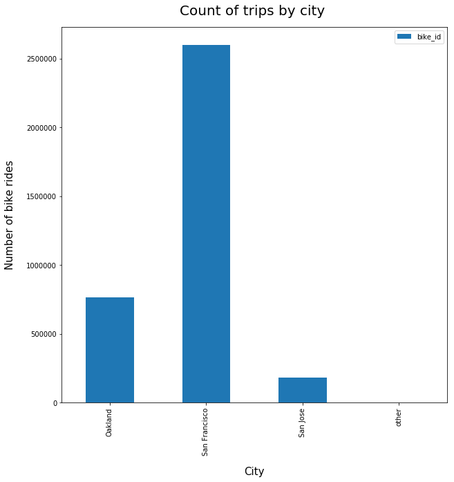

```python
# count of bike rides by city
df_copy.groupby(['city']).agg({'bike_id': 'count'}).plot(kind="bar", figsize = (10,10));
plt.title('Count of trips by city ', fontsize=20, y=1.02)
plt.xlabel('City', labelpad=16, fontsize=15)
plt.ylabel('Number of bike rides', labelpad=16, fontsize=15);
```

### Of the features you investigated, were there any unusual distributions? Did you perform any operations on the data to tidy, adjust, or change the form of the data? If so, why did you do this?

> Two of the variables I investigated in this set were not provided for me in the original dataset. The "Age" variable was not provided, I had to create it using the "Member Year of Birth" variable. It serves as a second major numeric variable in this analisys. I also used variable types releted geographical location: "Start Station Latitude", "Start Station Longitude", "End Station Latitude", "End Station Longitude" to create additional categorical variable "City" to explore data by each city. In addition to that I created new variable for trip duration in minutes. I converted variables for start and end of trips to date/time type. That allowed me to group data by year and month.

## Bivariate Exploration

```python
# explore variables of dataset
# numneric variables
num_var = ['duration_min', 'age']
# categorical variables
cat_var = ['member_gender', 'rental_access_method', 'user_type', 'city']
```

I start this section by arranging variables by their types in lists for the future use in plots. Also since the analysis makes sense only for realistic age group I filter the dataset to only include individuals of 60 years old or younger.

```python
# filter for realistic age, remove outliers for age
df_copy = df_copy[df_copy['age']<=60]
```

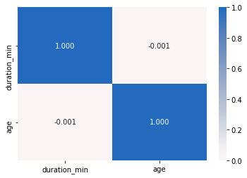

```python
# correlation plot
sb.heatmap(df_copy[num_var].corr(), annot = True, fmt = '.3f',
           cmap = 'vlag_r', center = 0);
```

The heat map shows very weak correlation between two variables.

```python
# adjust dataset for trip duration under 40 min
df_duration_correct2 = df_copy[df_copy['duration_min'] <= 40]
```

[figure not shown]

```python
# scatter plot of 10000 bike trips sample, duraton of trip according to age
plt.figure(figsize = [12,12])
samples = np.random.choice(df_duration_correct2.shape[0], 10000, replace = False);
df_samp = df_duration_correct2.loc[samples,:]
plt.scatter(data = df_samp, x = 'age', y = 'duration_min', alpha = 0.2);
plt.title('Trip Duration(min) Against Age ', fontsize=20, y=1.02);
plt.xlabel('Age', labelpad=16, fontsize=15);
plt.ylabel('Trip Duration(min)', labelpad=16, fontsize=15);
```

I decided to explore correlation between age and duration of trips again with a scatter plot on a sample of 10000 trips and applied alpha property for transperancy. The scatter plot does not show strong correlation between two variables. However the plot shows some expected tendencies such as older people taking less longer trips. In addition it is apparant from the plot that the most of the trips are attempted by people in the age between 25 and 40 years old.

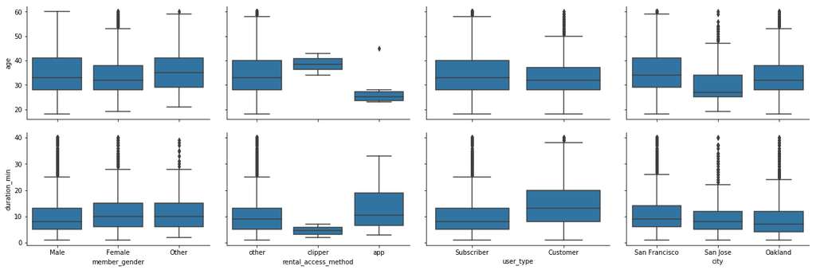

```python
# matrix plot of 10000 bike trips comparing categorical and numeric variables
#Reference:
plt.figure(figsize = [8, 5])
samples = np.random.choice(df_duration_correct2.shape[0], 10000, replace = False)
df_samp = df_duration_correct2.loc[samples,:]

def boxgrid(x, y, **kwargs):
    """ Quick hack for creating box plots with seaborn's PairGrid. """
    default_color = sb.color_palette()[0]
    sb.boxplot(x, y, color = default_color);

plt.figure(figsize = [10, 10])
g = sb.PairGrid(data = df_samp, y_vars = ['age', 'duration_min'], x_vars = cat_var,
                size = 3, aspect = 1.5);
g.map(boxgrid);
plt.show();
```

From this collection of box plots I can point out following relations. Between trip duration and user type - customers tend to take longer trips then subscrubers. Subscribers tend to be slightly older than customers. Female bikers tend to take slightly longer trips. Population of bikers in San Francisco tend to be the oldest, and yongest population of riders in San Jose.

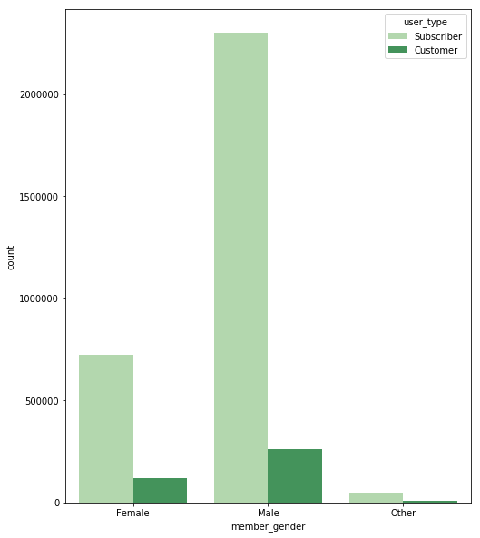

```python
# bar plot of distribution categorical variable of member gender to user type
plt.figure(figsize = [8, 10])
sb.countplot(data = df_copy, x = 'member_gender', hue = 'user_type', palette = 'Greens');
```

Bar plot above shows how subscriber type is prevalent among all represented genders of bike riders.

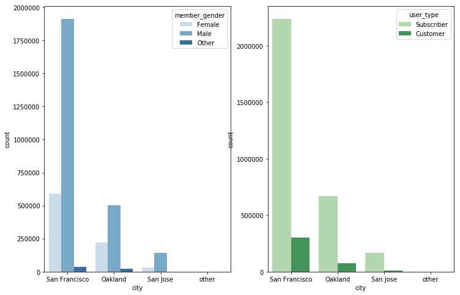

```python
# subplot of gender and user type by city location
plt.figure(figsize = [12, 8])
plt.subplot(1, 2, 1)
sb.countplot(data = df_copy , x = 'city', hue = 'member_gender', palette = 'Blues');

plt.subplot(1, 2, 2)
sb.countplot(data = df_copy, x = 'city', hue = 'user_type', palette = 'Greens');
```

In the subplot I attempted to explore the distribution of categorical variables for memeber gender and user type according to each city. However, I've noticed that this plot misrepresents the data, because it compares by number of bike rides for each city. Since San Francisco has overall significantly larger number of bike rides overall it stands out too much on the plot making comparing gender and user type amount difficult.

To fix that problem I decided to calculate percentage for each gender and user type from the total amount of rides for each city and plot the percentage diffirence. In order to do so I created mask for from the dataset using groupby and agg methods.

```python
# mask for gender percentage
gen_pc = df_copy.groupby(['city', 'member_gender']).agg({'bike_id': 'count'})
```

```python
# mask for user type percentage
user_pc = df_copy.groupby(['city', 'user_type']).agg({'bike_id': 'count'})
```

```python
gen_pc
```

| city | member_gender | bike_id |
| --- | --- | --- |
| Oakland | Female | 226174 |
|  | Male | 518152 |
|  | Other | 21758 |
| San Francisco | Female | 596979 |
|  | Male | 1968444 |
|  | Other | 36046 |
| San Jose | Female | 32981 |
|  | Male | 147478 |
|  | Other | 627 |
| other | Female | 55 |
|  | Male | 203 |
|  | Other | 10 |

```python
# calculate percentage from total bike rides for gender
gen_pcts = gen_pc.groupby(level=0).apply(lambda x:
                                                  100*x / float(x.sum()))
```

```python
# calculate percentage from total bike rides for user type
user_pcts = user_pc.groupby(level=0).apply(lambda x:
                                                  100*x / float(x.sum()))
```

```python
gen_pcts
```

| city | member_gender | bike_id |
| --- | --- | --- |
| Oakland | Female | 29.523394 |
|  | Male | 67.636447 |
|  | Other | 2.840159 |
| San Francisco | Female | 22.947765 |
|  | Male | 75.666633 |
|  | Other | 1.385602 |
| San Jose | Female | 18.212893 |
|  | Male | 81.440862 |
|  | Other | 0.346244 |
| other | Female | 20.522388 |
|  | Male | 75.746269 |
|  | Other | 3.731343 |

```python
user_pcts
```

| city | user_type | bike_id |
| --- | --- | --- |
| Oakland | Customer | 10.107508 |
|  | Subscriber | 89.892492 |
| San Francisco | Customer | 11.653762 |
|  | Subscriber | 88.346238 |
| San Jose | Customer | 6.888440 |
|  | Subscriber | 93.111560 |
| other | Customer | 17.537313 |
|  | Subscriber | 82.462687 |

In order to plot the results I will use index reset, I decided to make copies of sets just to be on a sefe side.

```python
gen_copy = gen_pcts.copy()
```

```python
user_copy = user_pcts.copy()
```

```python
gen_copy.reset_index(inplace=True)
```

```python
user_copy.reset_index(inplace=True)
```

```python
# result of dataframe for plotting gender percentage
gen_copy
```

|  | city | member_gender | bike_id |
| --- | --- | --- | --- |
| 0 | Oakland | Female | 29.523394 |
| 1 | Oakland | Male | 67.636447 |
| 2 | Oakland | Other | 2.840159 |
| 3 | San Francisco | Female | 22.947765 |
| 4 | San Francisco | Male | 75.666633 |
| 5 | San Francisco | Other | 1.385602 |
| 6 | San Jose | Female | 18.212893 |
| 7 | San Jose | Male | 81.440862 |
| 8 | San Jose | Other | 0.346244 |
| 9 | other | Female | 20.522388 |
| 10 | other | Male | 75.746269 |
| 11 | other | Other | 3.731343 |

```python
# result of dataset for plotting user type percentage
user_copy
```

|  | city | user_type | bike_id |
| --- | --- | --- | --- |
| 0 | Oakland | Customer | 10.107508 |
| 1 | Oakland | Subscriber | 89.892492 |
| 2 | San Francisco | Customer | 11.653762 |
| 3 | San Francisco | Subscriber | 88.346238 |
| 4 | San Jose | Customer | 6.888440 |
| 5 | San Jose | Subscriber | 93.111560 |
| 6 | other | Customer | 17.537313 |
| 7 | other | Subscriber | 82.462687 |

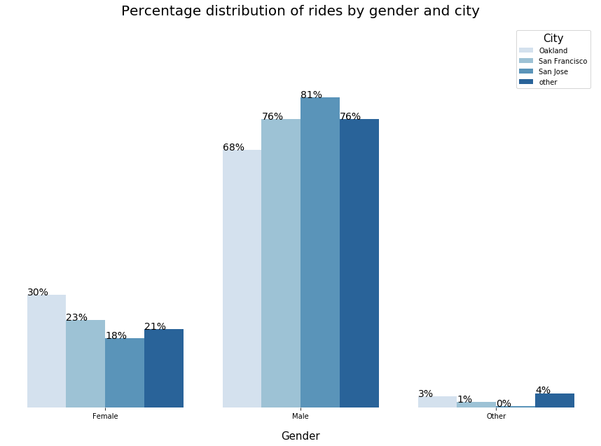

```python
# bar plot for gender distribution among cities
plt.figure(figsize=(15, 10))
ax = sb.barplot(x='member_gender',y = 'bike_id', hue = 'city', data = gen_copy, palette = 'Blues');
ax.set(ylim=(0, 100));
ax.set_yticks(np.arange(0, 100 +10, 10));
plt.title('Percentage distribution of rides by gender and city', fontsize=20, y=1.02);
plt.xlabel('Gender', labelpad=16, fontsize=15);
leg = plt.legend();
leg.set_title('City',prop={'size':15})
plt.gca().yaxis.set_major_formatter(PercentFormatter(100));
plt.box(on=None);
plt.gca().axes.get_yaxis().set_visible(False);
for p in ax.patches:
    width, height = p.get_width(), p.get_height()
    x, y = p.get_xy()
    ax.annotate('{:.0%}'.format(height/100), (x, y + height ), fontsize=14)
```

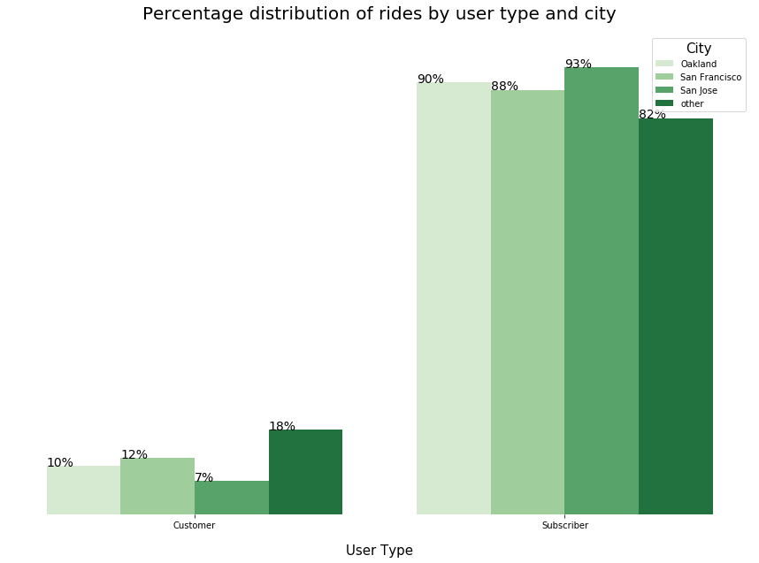

```python
# bar plot for user type  distribution among cities
plt.figure(figsize=(15, 10))
ax = sb.barplot(x='user_type',y = 'bike_id', hue = 'city', data = user_copy, palette = 'Greens');
ax.set(ylim=(0, 100));
ax.set_yticks(np.arange(0, 100 +10, 10));
plt.title('Percentage distribution of rides by user type and city', fontsize=20, y=1.02);
plt.xlabel('User Type', labelpad=16, fontsize=15);
leg = plt.legend();
leg.set_title('City',prop={'size':15});
plt.gca().yaxis.set_major_formatter(PercentFormatter(100));
plt.box(on=None);
plt.gca().axes.get_yaxis().set_visible(False);

for p in ax.patches:
    width, height = p.get_width(), p.get_height()
    x, y = p.get_xy()
    ax.annotate('{:.0%}'.format(height/100), (x, y + height ), fontsize=14)
```

### Talk about some of the relationships you observed in this part of the investigation. How did the feature(s) of interest vary with other features in the dataset?

> I observed weak correlation between two numeric variables of the dataset, age and trip duration. However, scatter plot of the relations showed that older people are taking less longer trips and that most of the trips are attempted by people in the age between 25 and 40 years old. Female bikers tend to take slightly longer trips. Population of bikers in San Francisco tend to be the oldest, and yongest population of riders in San Jose. I have noticed that comparing gender and user type distribution only besed on count of trips is confusing due to very big difference on total number of users between three cities. Therefore, I decided to use percentages. I have found that San Jose contains the largest percent of male bikers and Oakland has the lergest percent of female bikers. Among three cities the most percentage of bikers the largest percent of subscriber user type is in San Jose, and largest percent of customer user type is in San Francisco.

## Multivariate Exploration

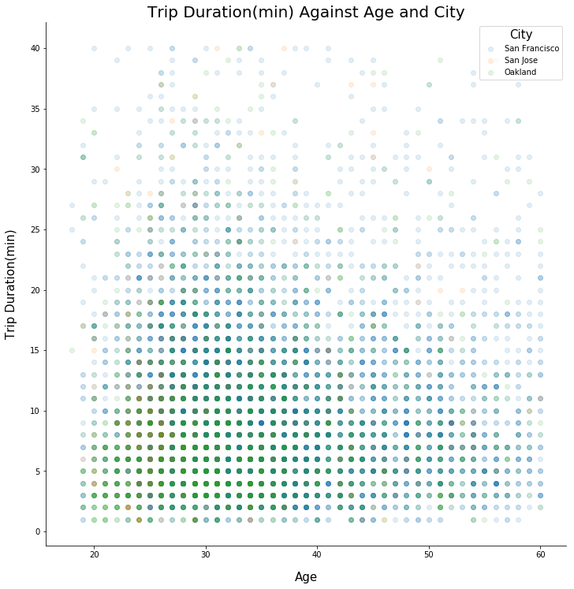

```python
# scatter plot of duraton of trip according to age by city

g = sb.FacetGrid(data = df_samp, hue = 'city', height = 10)
g.map(plt.scatter, 'age','duration_min', alpha = 1/8);
plt.title('Trip Duration(min) Against Age and City', fontsize=20, y=1.02);
plt.xlabel('Age', labelpad=16, fontsize=15);
plt.ylabel('Trip Duration(min)', labelpad=16, fontsize=15);
leg = plt.legend();
leg.set_title('City',prop={'size':15});
```

The scatter plot of distribution of age and trip duration by city shows that in San Jose and Oakland people are taking shorter trips compared to San Francisco. In addition to that San Francisco shows larger number of older bikers compared to other two cities.

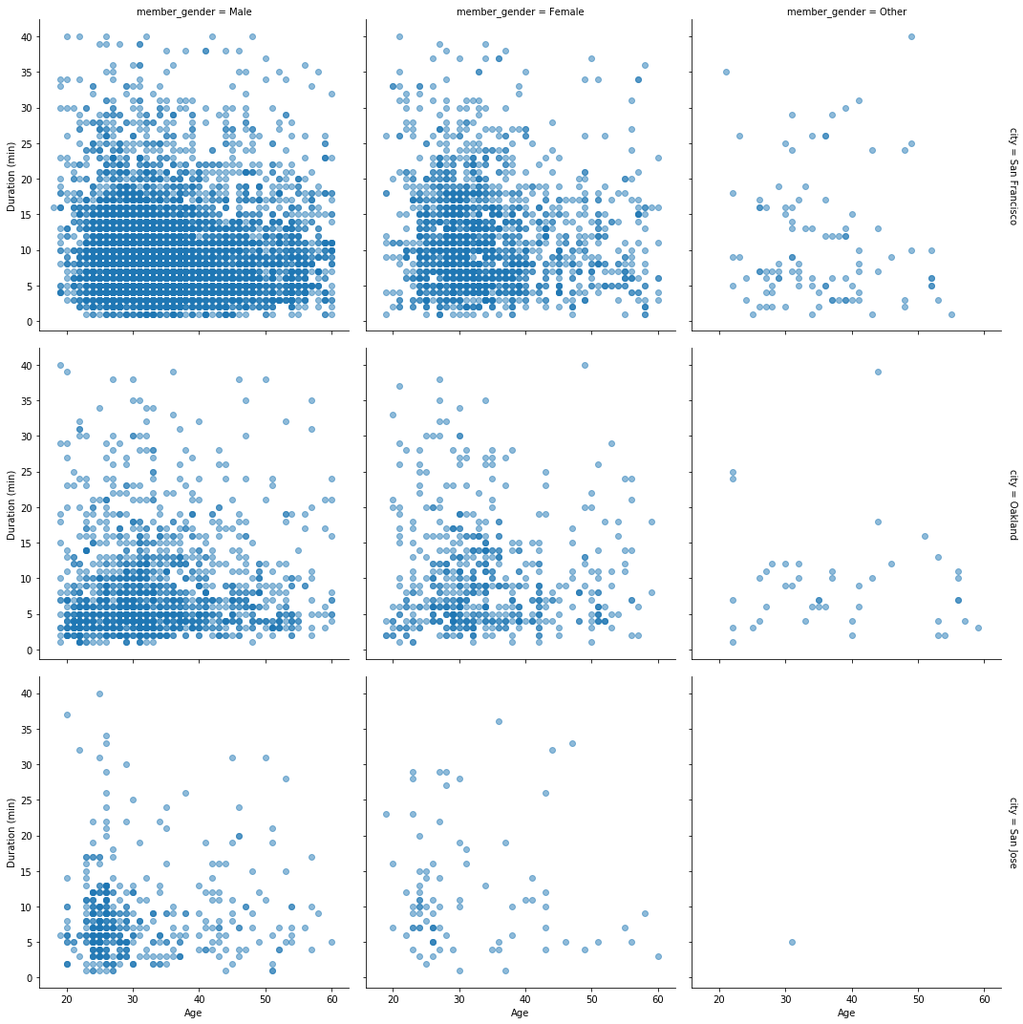

```python
# matrix plot of 10000 bike rides sample comparing age, gender and trip duration by each city
samples = np.random.choice(df_duration_correct2.shape[0], 10000, replace = False)
df_samp2 = df_duration_correct2.loc[samples,:]

g = sb.FacetGrid(data = df_samp2 , col = 'member_gender', row = 'city', size = 5,  margin_titles = True)
g.map(plt.scatter, 'age', 'duration_min', alpha = 0.5);
g.set_xlabels('Age');
g.set_ylabels('Duration (min)');

plt.show();
```

Therefore I decided to try a box plot for trip duration based on member gender and city. The box plot below is showing interesting tendency of female bikers taking longer trips in all of the three cities.

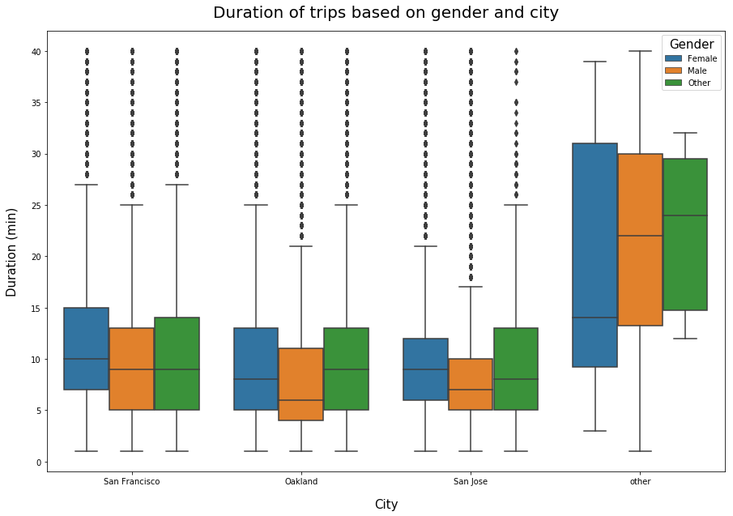

```python
# boxplot for trip duration distribution based on gender and city
plt.figure(figsize = [15, 10])
sb.boxplot(data = df_duration_correct2, x='city', y='duration_min', hue='member_gender');
plt.title('Duration of trips based on gender and city', fontsize=20, y=1.02);
plt.xlabel('City',labelpad=16, fontsize=15);
plt.ylabel('Duration (min)',labelpad=16, fontsize=15);
leg = plt.legend();
leg.set_title('Gender',prop={'size':15});
```

In order to compare overall trend of bike rides for each city. I ones angain used groupby() method applied to year, month, and city to create dataframe. Then I used agg() method to aggregate by bike id count in concert with unstuck() method to plot a line for each city.

From the plot below it is apparent that the number of rides overtime is following similar pattern across all three cities. However there is an interesting difference to be observed: on the right end of the plot starting around June of 2019 the number of bike rides in Oakland and San Jose are incresing. That is in comparison to San Francisco where number of bike rides at that time period is in a sharp decline.

```python
# arrange data by year/month and city
df_year_city = df_copy.groupby([df_copy['start_time'].dt.year, df_copy['start_time'].dt.month, 'city'])
```

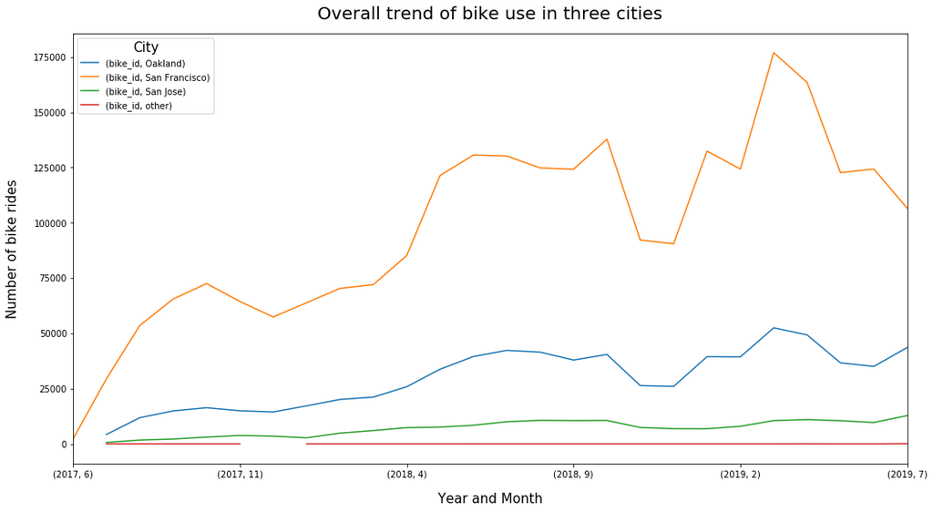

```python
# line plot of changes in bike use overtime for three cities
fig, ax = plt.subplots(figsize=(17,9))
df_year_city.agg({'bike_id':'count'}).unstack().plot(ax=ax);
plt.title('Overall trend of bike use in three cities', fontsize=20,  y=1.02);
plt.xlabel('Year and Month',labelpad=16, fontsize=15);
plt.ylabel('Number of bike rides',labelpad=16, fontsize=15);
leg = ax.legend()
leg.set_title('City',prop={'size':15})
ax = plt.gca();
```

### Talk about some of the relationships you observed in this part of the investigation. Were there features that strengthened each other in terms of looking at your feature(s) of interest?

> The scatter plot of distribution of age and trip duration by city shows that in San Jose and Oakland people are taking shorter trips compared to San Francisco. In addition to that San Francisco shows larger number of older bikers compared to other two cities. All three cities showed one trend of female bikers taking longer trips than male bikers.

### Were there any interesting or surprising interactions between features?

> The overall trend of bike use followed same line pattern for most of the duration of the time frame available for this analisys. However, very recently trend started to change and we can observe that growth of bike rides in Oakland and San Jose compared with decline in San Francisco.